## 2018시즌 타일러 글라스노우 데이터 시각화

https://baseballsavant.mlb.com/를 통해 2018시즌 타일러 글라스노우의 csv를 바탕으로 시각화 자료를 만들고자 합니다.

시각화에 사용할 raw data의 파일명은 607192_data_18.csv입니다.

```r
tg2018 <- read.csv("C:/Users/Administrator/Desktop/backup/R/1/607192_data_18.csv")
knitr::kable(tg2018 [1:5, 1:7])
```

| pitch_type | game_date | release_speed | release_pos_x | release_pos_z | player_name | batter |
| --- | --- | --- | --- | --- | --- | --- |
| FF | 2018-09-28 | 96.2 | -2.0605 | 5.7339 | Tyler Glasnow | 596105 |
| FF | 2018-09-28 | 94.7 | -1.9515 | 5.8175 | Tyler Glasnow | 596105 |
| FF | 2018-09-28 | 96.4 | -1.9074 | 5.7711 | Tyler Glasnow | 596105 |
| FF | 2018-09-28 | 96.8 | -1.9883 | 5.8442 | Tyler Glasnow | 596105 |
| FF | 2018-09-28 | 95.2 | -1.9130 | 5.8809 | Tyler Glasnow | 596105 |

포심 패스트볼의 시각화를 위해 dplyr 패키지를 사용하여 구종 분류합니다. 또한, 베이스볼 서번트와 같은 시각화를 위해 베이스볼서번트에서 사용되는 사진 파일 또한 불러오도록 하겠습니다.

### 포심 패스트볼 분류 하기 (dplyr 패키지 사용)

```r
library(dplyr)
FF_2018 <- filter(tg2018, pitch_type == 'FF')
```

데이터 시각화에 주로 사용되는 ggplot2를 이용하여 타일러 글라스노우의 포심 패스트볼의 시각화를 하도록 하겠습니다. 가상의 스트라이크 존 사진을 불러오고 좌표를 맞추기 위해 png & grid 패키지를 사용하였습니다. 밀도의 확인을 위해 원래 베이스볼 서번트 자료와는 달리 투명도를 주었습니다.

### 포심 패스트볼 Pitch Chart

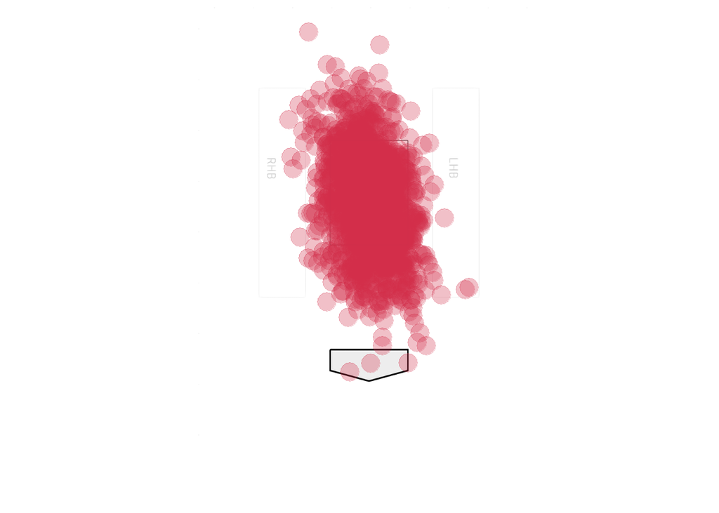

```r
library(ggplot2)

library(png)

library(grid)

image1 <- readPNG("C:/Users/Administrator/Desktop/backup/R/1/baseballsavant_1.png")

ggplot() + annotation_custom(rasterGrob(image1, width = unit(1,"npc"), height = unit(1,"npc")), -Inf, Inf, -Inf, Inf) + theme_minimal()+xlim(-4, 4) + ylim(-2.5, 6) + scale_alpha(range=c(0.01, 0.9)) + geom_point(data = FF_2018, aes(x=plate_x, y=plate_z),colour = "#d22d49", size = 6, alpha= 0.3)+ theme(axis.text.x=element_blank()) + theme(axis.text.y=element_blank(),)+xlab("") + ylab("")+coord_fixed(ratio = 1.3)
```

이제 지금까지 나온 데이터를 바탕으로 Pitch Hitmap을 그려보도록 하겠습니다. 베이스볼 서번트에서 사용되는 plotly 패키지는 유료이기 때문에 사룡하기 힘들기 때문에 히트맵 효과를 주기 위해 ggplot2의 ’stat_density_2d’를 사용하겠습니다.

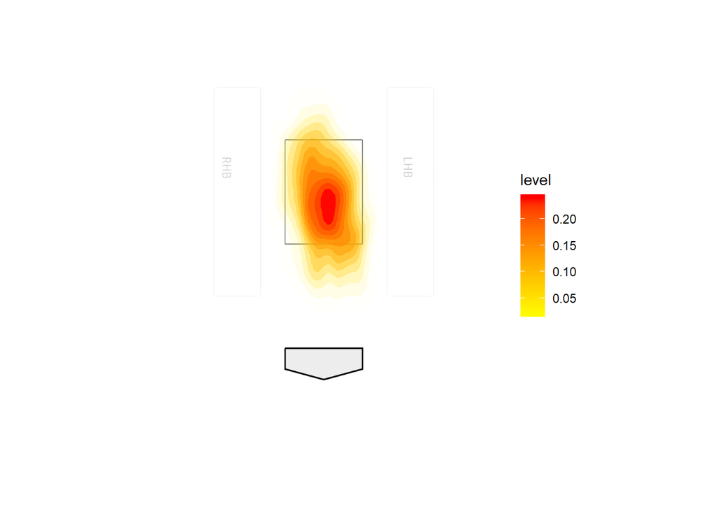

```r
ggplot() + annotation_custom(rasterGrob(image1, width = unit(1,"npc"), height = unit(1,"npc")), -Inf, Inf, -Inf, Inf) + stat_density_2d(data = FF_2018, aes(x=plate_x, y=plate_z, fill = ..level.., alpha = ..level..,), geom = "polygon")+ theme_minimal()  +xlim(-4, 4) + ylim(-2.5, 6) + scale_fill_gradient(low='#fffa00', high='#ff0000') + scale_alpha(range=c(0.01, 0.9), guide=F) + theme(axis.text.x=element_blank()) + theme(axis.text.y=element_blank())+xlab("") + ylab("") + coord_fixed(ratio = 1.3)
```